# Practical Machine Learning Project

**Main Question:** Can we use quantitative data from accelerometers on wearable devices such as Jawbone Up, Nike FuelBand, and Fitbit to classify how well a person if performing an activity (e.g., barbell lifts)?

**Input Data:** We are provided links to a Training dataset and a Testing dataset

** Discussion:** The goal of the project is to predict the manner in which the exercise was done. The “classe” variable in the Training Dataset provides classification information on how well someone has performed the activity. The first step is to load the Training dataset and examine the data.

```r
library(caret)
library(gbm)
set.seed(3433)
trainingdata <- read.csv(Path_to_Training)

## Let's look at the dimensions of the trainingdata dataframe
print("Dimensions of Training Data")
```

```
## [1] "Dimensions of Training Data"
```

```r
dim(trainingdata)
```

```
## [1] 19622   160
```

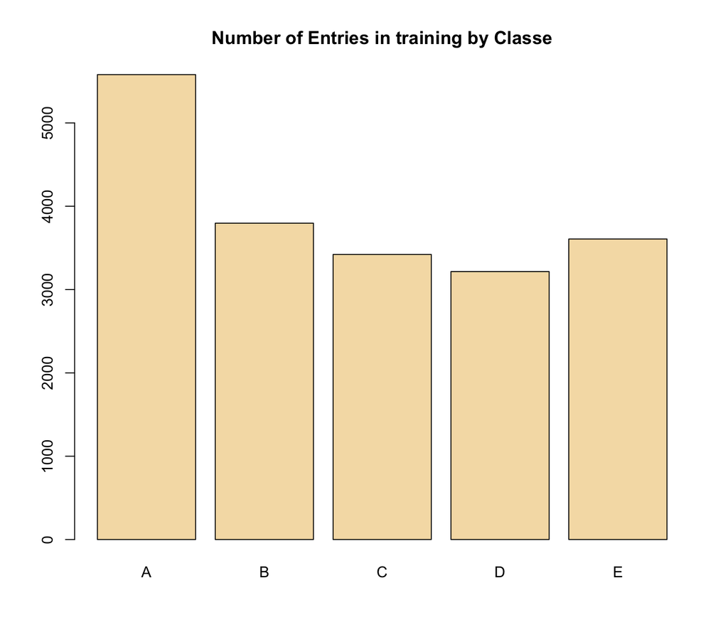

```r
## We are also loading Testing Data into a Data Frame.
## But we don't do anything with it for now...
testingdata <- read.csv(Path_to_Testing)

## Plot entries by Classe
barplot(table(trainingdata$classe), col = "wheat", main = "Number of Entries in training by Classe")
```

**Prediction Study Design:** We first take the training data file, and further split into a training set and a testing set. Also, since this is a **classification problem**, we will be using **Accuracy** as a measure to evaluate the Machine Learning Models.

We will split the trainingdata dataset further into a training set and a testing set, using p = 0.75 for training. We want to use as much as possible for training.

```r
inTrain <- createDataPartition(y = trainingdata$classe, p = 0.75, list = FALSE)
training <- trainingdata[inTrain,]
testing <- trainingdata[-inTrain,]
```

**Features:** Since the problem we are solving specifically asks to predict on the basis of accelerometer data, we will only use accelerometer variables. Out of the 160 possible predictors, we focus on the following 20 predictors:

total-accel-belt, var-total-accel-belt, accel-belt-x, accel-belt-y, accel-belt-z, total-accel-arm, var-accel-arm, accel-arm-x, accel-arm-y, accel-arm-z, total-accel-dumbbell, var-accel-dumbbell, accel-dumbbell-x, accel-dumbbell-y, accel-dumbbell-z, total-accel-forearm, var-accel-forearm, accel-forearm-x, accel-forearm-y, accel-forearm_z

The first step is now to eliminate any predictors for which we have missing values or NA values.

```r
## We use the following code to identify if a specific column has NA values

sum(is.na(training$var_accel_dumbbell))
```

```
## [1] 14401
```

Using the sample code above, we determined that the following 4 predictors should not be used in modeling because they have a significant number of NA values:

var-total-accel_belt, var-accel-arm, var-accel-dumbbell, var-accel-forearm

**Algorithm:** Since this is a classification problem, and the classe variable can have five values (A, B, C, D and E), I decided to use Random Forests, Boosting Trees and Linear Discriminant Analysis as potential algorithms to test. I will also be using a stacked prediction algorithm using Random Forests to see if combining the predictors will result in improved accuracy. See code below:

```r
### Random Forests Algorithm
mod3RF <- train( classe ~ total_accel_belt + accel_belt_x +  accel_belt_y +  accel_belt_z +
                   total_accel_arm + accel_arm_x + accel_arm_y + accel_arm_z + total_accel_dumbbell +
                   accel_dumbbell_x + accel_dumbbell_y + accel_dumbbell_z + total_accel_forearm +
                   accel_forearm_x + accel_forearm_y + accel_forearm_z, method = "rf", data =
                   training)
pred3RF <- predict(mod3RF, testing)

RFtable <- table(pred3RF, testing$classe)
RFtable
```

```
##
## pred3RF    A    B    C    D    E
##       A 1349   33   11   22    4
##       B    4  869   20    1   14
##       C   18   33  814   33    7
##       D   23    7    8  741   12
##       E    1    7    2    7  864
```

```r
RFAccuracy <- sum(diag(RFtable))/sum(colSums(RFtable))
cat("RF Accuracy =", RFAccuracy)
```

```
## RF Accuracy = 0.9455546
```

```r
## Checking in-sample error (which we expect to be much higher than
## out-of-sample error, which was RFAccuracy)

pred3RF_training <- predict(mod3RF, training)
RFtable_training <- table(pred3RF_training, training$classe)
RFAccuracy_training <- sum(diag(RFtable_training))/sum(colSums(RFtable_training))
cat("In-Sample RF Accuracy (based on the training dataset) =", RFAccuracy_training)
```

```
## In-Sample RF Accuracy (based on the training dataset) = 1
```

```r
### Boosted Trees Algorithm
mod3GBM <- train( classe ~ total_accel_belt + accel_belt_x +  accel_belt_y +  accel_belt_z +
                    total_accel_arm + accel_arm_x + accel_arm_y + accel_arm_z + total_accel_dumbbell +
                    accel_dumbbell_x + accel_dumbbell_y + accel_dumbbell_z + total_accel_forearm +
                    accel_forearm_x + accel_forearm_y + accel_forearm_z, method = "gbm", data =
                    training, verbose = FALSE)
pred3GBM <- predict(mod3GBM, testing)

GBMtable <- table(pred3GBM, testing$classe)
GBMtable
```

```
##
## pred3GBM    A    B    C    D    E
##        A 1238   91   68   72   21
##        B   25  689   49   14   59
##        C   55  105  715   45   44
##        D   76   25   20  655   39
##        E    1   39    3   18  738
```

```r
GBMAccuracy <- sum(diag(GBMtable))/sum(colSums(GBMtable))
cat("GBM Accuracy =", GBMAccuracy)
```

```
## GBM Accuracy = 0.8227977
```

```r
### Linear Discriminant Analysis
mod3LDA <- train( classe ~ total_accel_belt + accel_belt_x +  accel_belt_y +  accel_belt_z +   total_accel_arm + accel_arm_x + accel_arm_y + accel_arm_z + total_accel_dumbbell + accel_dumbbell_x + accel_dumbbell_y + accel_dumbbell_z + total_accel_forearm + accel_forearm_x + accel_forearm_y + accel_forearm_z, method = "lda", data = training)
pred3LDA <- predict(mod3LDA, testing)

LDAtable <- table(pred3LDA, testing$classe)
LDAtable
```

```
##
## pred3LDA   A   B   C   D   E
##        A 940 269 421 135 144
##        B  63 375  62  49 188
##        C 122 169 281  65  77
##        D 246  90  85 486 117
##        E  24  46   6  69 375
```

```r
LDAAccuracy <- sum(diag(LDAtable))/sum(colSums(LDAtable))
cat("LDA Accuracy =", LDAAccuracy)
```

```
## LDA Accuracy = 0.5010196
```

```r
### Stacking the Models together

predDF <- data.frame(pred3RF, pred3GBM, pred3LDA, classe = testing$classe)
combModFit <- train(classe ~ ., method = "rf", data = predDF)
combPred <- predict(combModFit, predDF)

Combtable <- table(combPred, testing$classe)
Combtable
```

```
##
## combPred    A    B    C    D    E
##        A 1349   33   11   22    4
##        B    4  869   20    1   14
##        C   18   33  814   33    7
##        D   23    7    8  741   12
##        E    1    7    2    7  864
```

```r
CombAccuracy <- sum(diag(Combtable))/sum(colSums(Combtable))
cat("Stacked Model Accuracy =", CombAccuracy)
```

```
## Stacked Model Accuracy = 0.9455546
```

**Discussion on in-sample error / accuracy and out-of-sample error / accuracy:** We expect the in-sample error to be much smaller (optimistic) than the out-of-sample error. In the code above, using Random Forests as an example, the **in-sample accuracy**, RFAccuracy_training = 1 (perfect), where as the **out-of-sample accuracy** (RFAccuracy) is 0.94.

The stacked model accuracy is the same as the accuracy using Random Forests.

**Prediction:** I am now using the models developed above to predict the classe variable for the real testingdata. Please see code below:

```r
testdataPred3RF <- predict(mod3RF, testingdata)
testdataPred3RF
```

```
##  [1] B A C A A E D B A A B C B A E E A B B B
## Levels: A B C D E
```

```r
testdataPred3GBM <- predict(mod3GBM, testingdata)
testdataPred3GBM
```

```
##  [1] A A C A A E D D A A A C B A E B A D B B
## Levels: A B C D E
```

```r
testdataPred3LDA <- predict(mod3LDA, testingdata)
testdataPred3LDA
```

```
##  [1] B A A A A E D E A A A A B A C B E A B B
## Levels: A B C D E
```

```r
predVDF <- data.frame(pred3RF = testdataPred3RF, pred3GBM = testdataPred3GBM, pred3LDA = testdataPred3LDA)

combPredV <- predict(combModFit, predVDF)
combPredV
```

```
##  [1] B A C A A E D B A A B C B A E E A B B B
## Levels: A B C D E
```

**Conclusion:** Based on accuracy of the Random Forests algorithm (and the stacked model), the prediction for the 20 test cases is provided below:

```r
testdataPred3RF
```

```
##  [1] B A C A A E D B A A B C B A E E A B B B
## Levels: A B C D E
```

```r
combPredV
```

```
##  [1] B A C A A E D B A A B C B A E E A B B B
## Levels: A B C D E
```